# GGplot2 Extension

## Data

Every layer must have some data associated with it, and that data must be in a tidy data frame. You’ll learn about tidy data in Chap. 9, but for now, all you need to know is that a tidy data frame has variables in the columns and observations in the rows. This is a strong restriction, but there are good reasons for it:

1. Your data is very important, so it’s best to be explicit about it.
2. A single data frame is also easier to save than a multitude of vectors, which means it’s easier to reproduce your results or send your data to someone else.
3. It enforces a clean separation of concerns: ggplot2 turns data frames into visualisations. Other packages can make data frames in the right format (learn more about that in Sect. 11.4).
- The data on each layer doesn’t need to be the same, and it’s often useful to combine multiple datasets in a single plot. To illustrate that idea I’m going to generate two new datasets related to the mpg dataset. First I’ll fit a loess model and generate predictions from it. (This is what geom smooth() does behind the scenes.)

```r
library(ggplot2)
library(dplyr)
library(gridExtra)
library(mgcv)
library(MASS)
library(directlabels)

mod <- loess(hwy ~ displ, data = mpg)
grid <- data_frame(displ = seq(min(mpg$displ), max(mpg$displ), length = 50))
grid$hwy <- predict(mod, newdata = grid)
grid$hwy
```

```
 [1] 33.09286 32.16100 31.26635 30.41403 29.60168 28.82979 28.09612 27.39752
 [9] 26.73611 26.11707 25.52830 24.99810 24.53340 24.09418 23.64634 23.21696
[17] 22.80828 22.40978 22.01095 21.60128 21.17025 20.70708 20.19083 19.63934
[25] 19.08893 18.57596 18.13676 17.80767 17.58594 17.40438 17.26494 17.17248
[33] 17.13186 17.14795 17.22433 17.35357 17.53353 17.76418 18.04546 18.37732
[41] 18.75972 19.19262 19.67595 20.20968 20.79376 21.42814 22.11278 22.84761
[49] 23.63261 24.46771
```

```r
grid
```

```
# A tibble: 50 x 2
   displ   hwy
   <dbl> <dbl>
 1  1.6   33.1
 2  1.71  32.2
 3  1.82  31.3
 4  1.93  30.4
 5  2.04  29.6
 6  2.15  28.8
 7  2.26  28.1
 8  2.37  27.4
 9  2.48  26.7
10  2.59  26.1
# … with 40 more rows
```

- Next, I’ll isolate observations that are particularly far away from their predicted values:

```r
library(ggplot2)
library(dplyr)
library(gridExtra)
library(mgcv)
library(MASS)
library(directlabels)

std_resid <- resid(mod) / mod$s
outlier <- filter(mpg, abs(std_resid) > 2)
outlier
```

```
# A tibble: 6 x 11
  manufacturer model   displ  year   cyl trans   drv     cty   hwy fl    class
  <chr>        <chr>   <dbl> <int> <int> <chr>   <chr> <int> <int> <chr> <chr>
1 chevrolet    corvet…   5.7  1999     8 manual… r        16    26 p     2seater
2 pontiac      grand …   3.8  2008     6 auto(l… f        18    28 r     midsize
3 pontiac      grand …   5.3  2008     8 auto(s… f        16    25 p     midsize
4 volkswagen   jetta     1.9  1999     4 manual… f        33    44 d     compact
5 volkswagen   new be…   1.9  1999     4 manual… f        35    44 d     subcom…
6 volkswagen   new be…   1.9  1999     4 auto(l… f        29    41 d     subcom…
```

- I’ve generated these datasets because it’s common to enhance the display of raw data with a statistical summary and some annotations. With these new datasets, I can improve our initial scatterplot by overlaying a smoothed line, and labelling the outlying points:

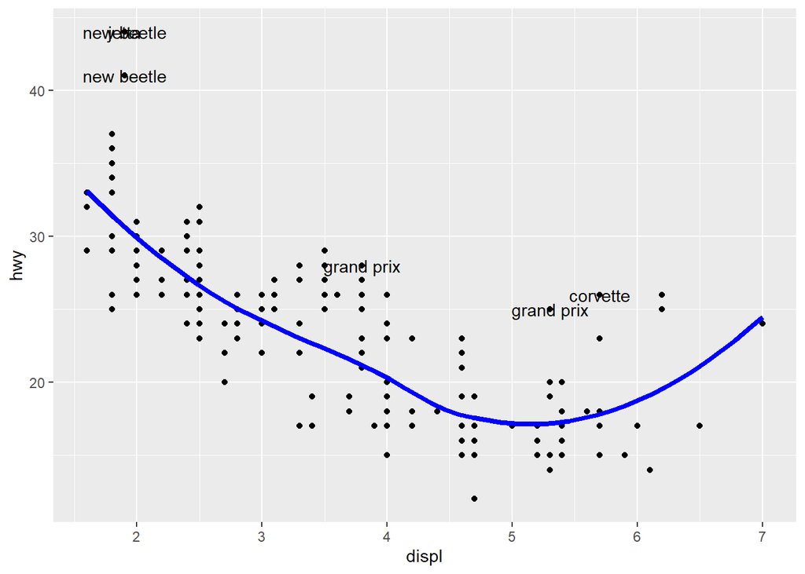

```r
library(ggplot2)
library(dplyr)
library(gridExtra)
library(mgcv)
library(MASS)
library(directlabels)

ggplot(mpg, aes(displ, hwy)) +
geom_point() +
geom_line(data = grid, colour = "blue", size = 1.5) +
geom_text(data = outlier, aes(label = model))
```

- (The labels aren’t particularly easy to read, but you can fix that with some manual tweaking.)
- Note that you need the explicit data = in the layers, but not in the call to ggplot(). That’s because the argument order is different. This is a little inconsistent, but it reduces typing for the common case where you specify the data once in ggplot() and modify aesthetics in each layer.
- In this example, every layer uses a different dataset. We could define the same plot in another way, omitting the default dataset, and specifying a dataset for each layer:

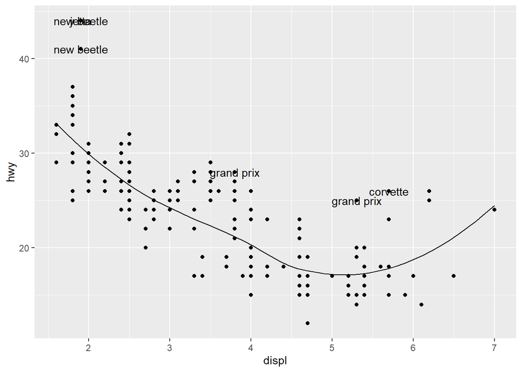

```r
library(ggplot2)
library(dplyr)
library(gridExtra)
library(mgcv)
library(MASS)
library(directlabels)

ggplot(mapping = aes(displ, hwy)) +
geom_point(data = mpg) +
geom_line(data = grid) +
geom_text(data = outlier, aes(label = model))
```

- I don’t particularly like this style in this example because it makes it less clear what the primary dataset is (and because of the way that the arguments to ggplot() are ordered, it actually requires more keystrokes). However, you may prefer it in cases where there isn’t a clear primary dataset, or where the aesthetics also vary from layer to layer.
- The following code uses dplyr to generate some summary statistics about each class of car (you’ll learn how it works in Chap. 10).

```r
library(ggplot2)
library(dplyr)
library(gridExtra)
library(mgcv)
library(MASS)
library(directlabels)

library(dplyr)
class <- mpg %>%
group_by(class) %>%
summarise(n = n(), hwy = mean(hwy))
class
```

```
# A tibble: 7 x 3
  class          n   hwy
  <chr>      <int> <dbl>
1 2seater        5  24.8
2 compact       47  28.3
3 midsize       41  27.3
4 minivan       11  22.4
5 pickup        33  16.9
6 subcompact    35  28.1
7 suv           62  18.1
```

## Aesthetic Mappings

- The aesthetic mappings, defined with aes(), describe how variables are mapped to visual properties or aesthetics. aes() takes a sequence of aesthetic-variable pairs like this: aes(x = displ, y = hwy, colour = class)
- (If you’re American, you can use color, and behind the scenes ggplot2 will correct your spelling;)
- Here we map x-position to displ, y-position to hwy, and colour to class.
- The names for the first two arguments can be omitted, in which case they correspond to the x and y variables. That makes this specification equivalent to the one above: aes(displ, hwy, colour = class)
- While you can do data manipulation in aes(), e.g. aes(log(carat), log(price)), it’s best to only do simple calculations. It’s better to move complex transformations out of the aes() call and into an explicit dplyr::mutate() call, as you’ll learn about in Sect. 10.3. This makes it easier to check your work and it’s often faster because you need only do the transformation once, not every time the plot is drawn.
- Never refer to a variable with $ (e.g., diamonds$carat) in aes(). This breaks containment, so that the plot no longer contains everything it needs, and causes problems if ggplot2 changes the order of the rows, as it does when facetting.

## Specifying the Aesthetics in the Plot vs. in the Layers

- Aesthetic mappings can be supplied in the initial ggplot() call, in individual layers, or in some combination of both. All of these calls create the same plot specification:

```r
library(ggplot2)
library(dplyr)
library(gridExtra)
library(mgcv)
library(MASS)
library(directlabels)

ggplot(mpg, aes(displ, hwy, colour = class)) +
geom_point()
```

```r
ggplot(mpg, aes(displ, hwy)) +
geom_point(aes(colour = class))
```

```r
ggplot(mpg, aes(displ)) +
geom_point(aes(y = hwy, colour = class))
```

```r
ggplot(mpg) +
geom_point(aes(displ, hwy, colour = class))
```

- If you only have one layer in the plot, the way you specify aesthetics doesn’t make any difference. However, the distinction is important when you start adding additional layers. These two plots are both valid and interesting, but focus on quite different aspects of the data:

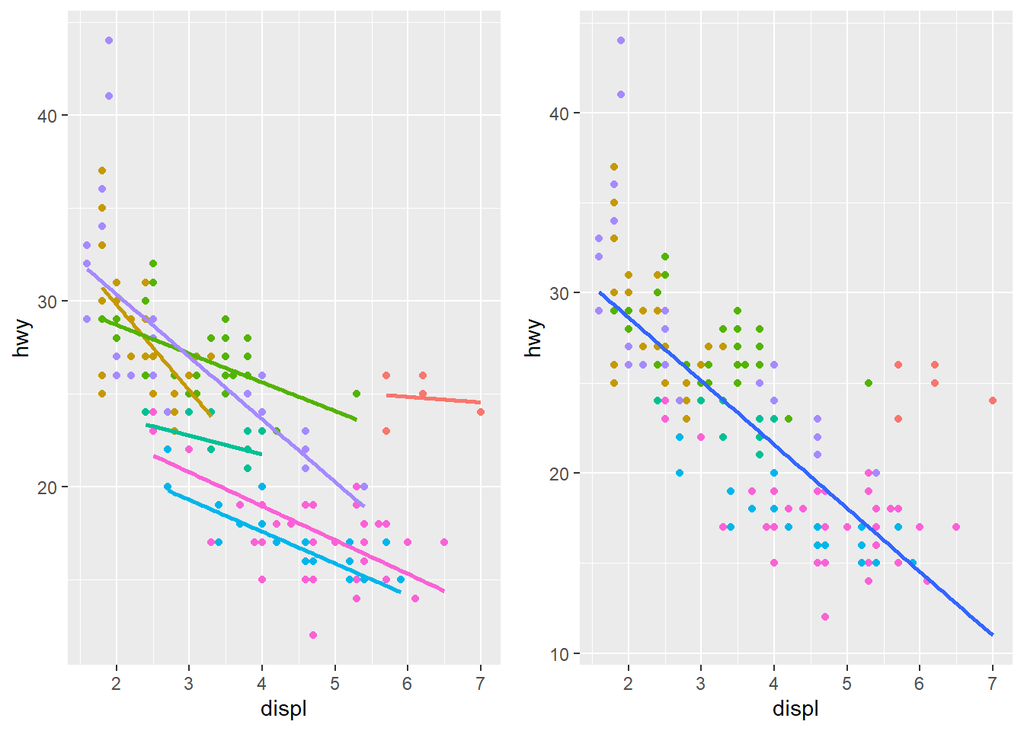

```r
library(ggplot2)
library(dplyr)
library(gridExtra)
library(mgcv)
library(MASS)
library(directlabels)

g1<-ggplot(mpg, aes(displ, hwy, colour = class)) +
geom_point() +
geom_smooth(method = "lm", se = FALSE) +
theme(legend.position = "none")

g2<-ggplot(mpg, aes(displ, hwy)) +
geom_point(aes(colour = class)) +
geom_smooth(method = "lm", se = FALSE) +
theme(legend.position = "none")

grid.arrange(g1,g2,ncol=2)
```

- Generally, you want to set up the mappings to illuminate the structure underlying the graphic and minimise typing. It may take some time before the best approach is immediately obvious, so if you’ve iterated your way to a complex graphic, it may be worthwhile to rewrite it to make the structure more clear.

## Setting vs. Mapping

- Instead of mapping an aesthetic property to a variable, you can set it to a single value by specifying it in the layer parameters.We map an aesthetic to a variable (e.g., aes(colour = cut)) or set it to a constant (e.g., colour = “red”). If you want appearance to be governed by a variable, put the specification inside aes(); if you want override the default size or colour, put the value outside of aes().
- The following plots are created with similar code, but have rather different outputs. The second plot maps (not sets) the colour to the value ‘darkblue’. This effectively creates a new variable containing only the value ‘darkblue’ and then scales it with a colour scale. Because this value is discrete, the default colour scale uses evenly spaced colours on the colour wheel, and since there is only one value this colour is pinkish.

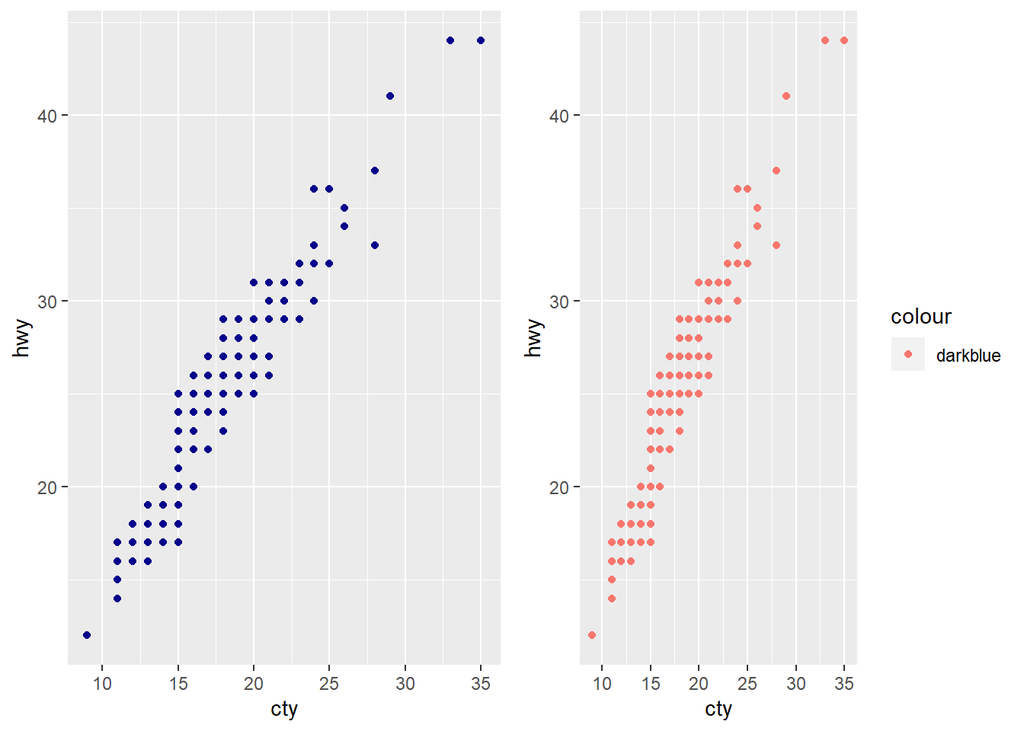

```r
library(ggplot2)
library(dplyr)
library(gridExtra)
library(mgcv)
library(MASS)
library(directlabels)

g1<-ggplot(mpg, aes(cty, hwy)) +
geom_point(colour = "darkblue")

g2<-ggplot(mpg, aes(cty, hwy)) +
geom_point(aes(colour = "darkblue"))

grid.arrange(g1,g2,ncol=2)
```

- A third approach is to map the value, but override the default scale:

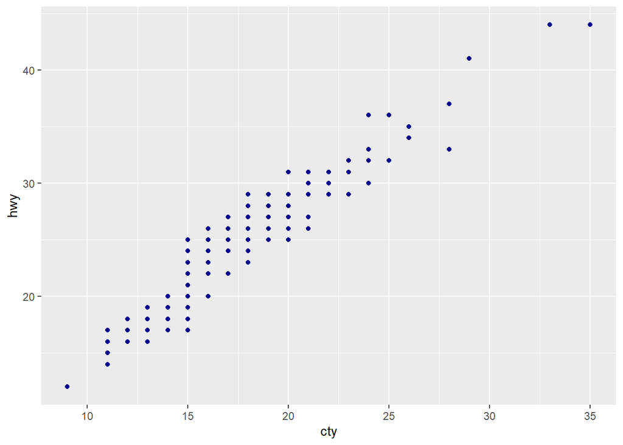

```r
library(ggplot2)
library(dplyr)
library(gridExtra)
library(mgcv)
library(MASS)
library(directlabels)

ggplot(mpg, aes(cty, hwy)) +
geom_point(aes(colour = "darkblue")) +
scale_colour_identity()
```

- This is most useful if you always have a column that already contains colours. You’ll learn more about that in Sect. 6.6.4. It’s sometimes useful to map aesthetics to constants. For example, if you want to display multiple layers with varying parameters, you can “name” each layer:

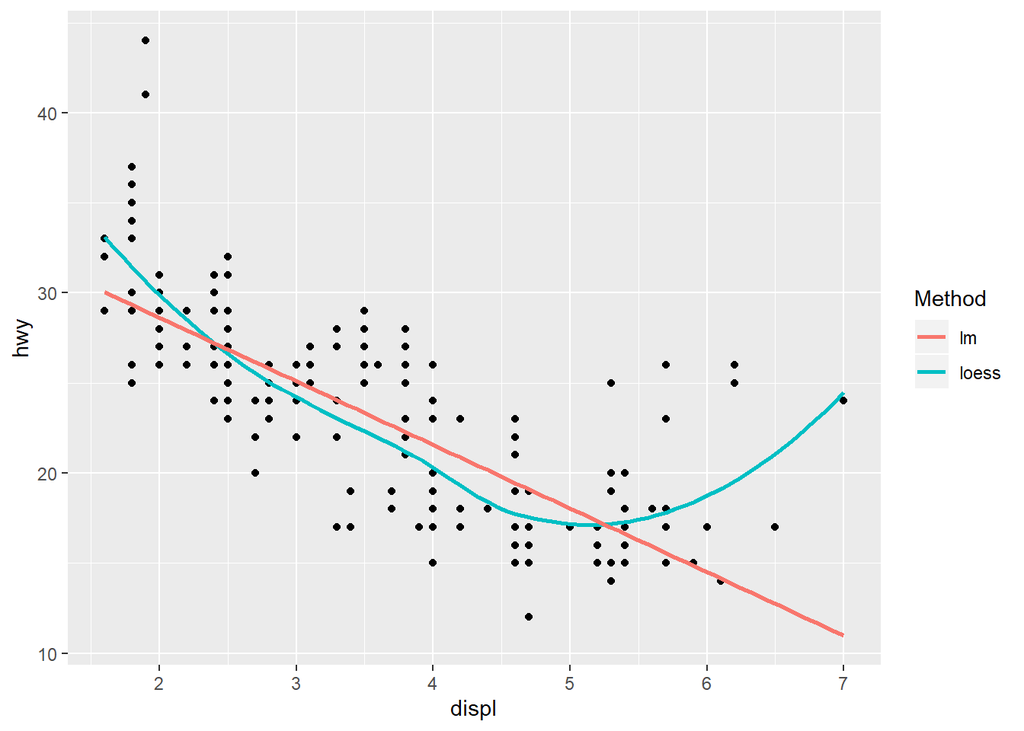

```r
library(ggplot2)
library(dplyr)
library(gridExtra)
library(mgcv)
library(MASS)
library(directlabels)

ggplot(mpg, aes(displ, hwy)) +
geom_point() +
geom_smooth(aes(colour = "loess"), method = "loess", se = FALSE) +
geom_smooth(aes(colour = "lm"), method = "lm", se = FALSE) +
labs(colour = "Method")
```

## Geoms

- Geometric objects, or geoms for short, perform the actual rendering of the layer, controlling the type of plot that you create. For example, using a point geom will create a scatterplot, while using a line geom will create a line plot.
- Graphical primitives:
1. geom blank(): display nothing. Most useful for adjusting axes limits using data.
2. geom point(): points.
3. geom path(): paths.
4. geom ribbon(): ribbons, a path with vertical thickness.
5. geom segment(): a line segment, specified by start and end position.
6. geom rect(): rectangles.
7. geom polyon(): filled polygons.
8. geom text(): text.
- One variable:

– Discrete: 1. geom bar(): display distribution of discrete variable.

- Continuous
1. geom histogram(): bin and count continuous variable, display with bars.
2. geom density(): smoothed density estimate.
3. geom dotplot(): stack individual points into a dot plot.
4. geom freqpoly(): bin and count continuous variable, display with lines.
- Two variables:

– Both continuous:

1. geom point(): scatterplot.
2. geom quantile(): smoothed quantile regression.
3. geom rug(): marginal rug plots.
4. geom smooth(): smoothed line of best fit.
5. geom text(): text labels.
- Show distribution:
1. geom bin2d(): bin into rectangles and count.
2. geom density2d(): smoothed 2d density estimate.
3. geom hex(): bin into hexagons and count.
- At least one discrete:
1. geom count(): count number of point at distinct locations.
2. geom jitter(): randomly jitter overlapping points.
- One continuous, one discrete:
1. geom bar(stat = “identity”): a bar chart of precomputed summaries.
2. geom boxplot(): boxplots.
3. geom violin(): show density of values in each group.
- One time, one continuous
1. geom area(): area plot.
2. geom line(): line plot.
3. geom step(): step plot.

– Display uncertainty:

1. geom crossbar(): vertical bar with center.
2. geom errorbar(): error bars.
3. geom linerange(): vertical line.
4. geom pointrange(): vertical line with center.

– Spatial

1. geom map(): fast version of geom polygon() for map data.
- Three variables:
1. geom contour(): contours.
2. geom tile(): tile the plane with rectangles.
3. geom raster(): fast version of geom tile() for equal sized tiles.
- Each geom has a set of aesthetics that it understands, some of which must be provided. For example, the point geoms requires x and y position, and understands colour, size and shape aesthetics. A bar requires height (ymax), and understands width, border colour and fill colour. Each geom lists its aesthetics in the documentation.
- Some geoms differ primarily in the way that they are parameterised. For example, you can draw a square in three ways:
1. By giving geom tile() the location (x and y) and dimensions (width and height).
2. By giving geom rect() top (ymax), bottom (ymin), left (xmin) and right (xmax) positions.
3. By giving geom polygon() a four row data frame with the x and y positions of each corner.
- Other related geoms are:
1. geom segment() and geom line().
2. geom area() and geom ribbon().
- If alternative parameterisations are available, picking the right one for your data will usually make it much easier to draw the plot you want.

## Stats

- A statistical transformation, or stat, transforms the data, typically by summarising it in some manner. For example, a useful stat is the smoother, which calculates the smoothed mean of y, conditional on x. You’ve already used many of ggplot2’s stats because they’re used behind the scenes to generate many important geoms:
1. stat bin(): geom bar(), geom freqpoly(), geom histogram()
2. stat bin2d(): geom bin2d()
3. stat bindot(): geom dotplot()
4. stat binhex(): geom hex()
5. stat boxplot(): geom boxplot()
6. stat contour(): geom contour()
7. stat quantile(): geom quantile()
8. stat smooth(): geom smooth()
9. stat sum(): geom count()
- You’ll rarely call these functions directly, but they are useful to know about because their documentation often provides more detail about the corresponding statistical transformation. Other stats can’t be created with a geom function:
1. stat ecdf(): compute a empirical cumulative distribution plot.
2. stat function(): compute y values from a function of x values.
3. stat summary(): summarise y values at distinct x values.
4. stat summary2d(), stat summary hex(): summarise binned values.
5. stat qq(): perform calculations for a quantile-quantile plot.
6. stat spoke(): convert angle and radius to position.
7. stat unique(): remove duplicated rows.
- There are two ways to use these functions. You can either add a stat () function and override the default geom, or add a geom () function and override the default stat:

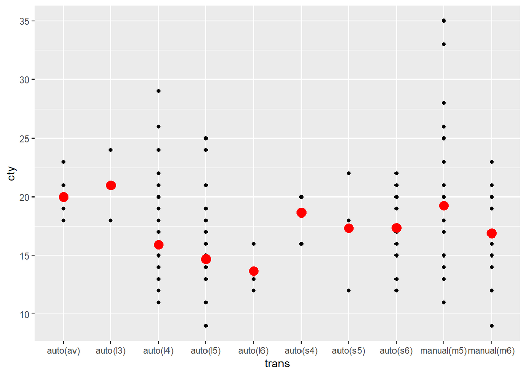

```r
library(ggplot2)
library(dplyr)
library(gridExtra)
library(mgcv)
library(MASS)
library(directlabels)

ggplot(mpg, aes(trans, cty)) +
geom_point() +
stat_summary(geom = "point", fun.y = "mean", colour = "red", size = 4)
```

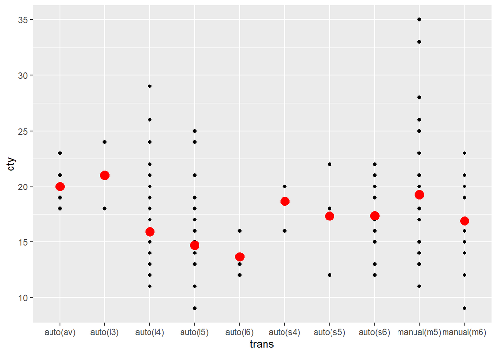

```r
ggplot(mpg, aes(trans, cty)) +
geom_point() +
geom_point(stat = "summary", fun.y = "mean", colour = "red", size = 4)
```

- I think it’s best to use the first form because it makes it more clear that you’re displaying a summary, not the raw data.

## Generated Variables

- Internally, a stat takes a data frame as input and returns a data frame as output, and so a stat can add new variables to the original dataset. It is possible to map aesthetics to these new variables. For example, stat bin, the statistic used to make histograms, produces the following variables:
1. count, the number of observations in each bin.
2. density, the density of observations in each bin (percentage of total/barwidth).
3. x, the centre of the bin.
- These generated variables can be used instead of the variables present in the original dataset. For example, the default histogram geom assigns the height of the bars to the number of observations (count), but if you’d prefer a more traditional histogram, you can use the density (density). To refer to a generated variable like density, “..” must surround the name. This prevents confusion in case the original dataset includes a variable with the same name as a generated variable, and it makes it clear to any later reader of the code that this variable was generated by a stat. Each statistic lists the variables that it creates in its documentation. Compare the y-axes on these two plots:

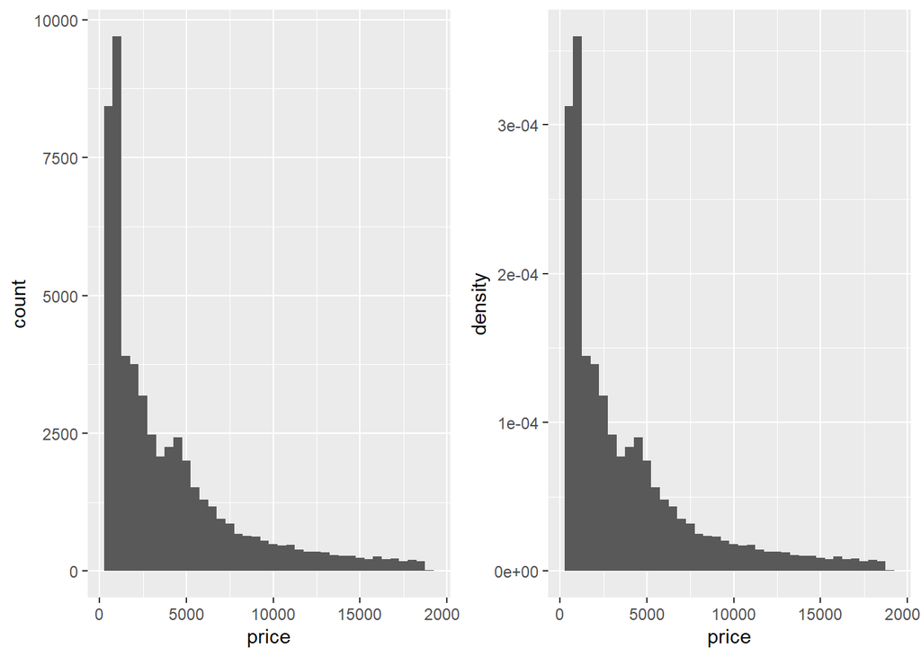

```r
library(ggplot2)
library(dplyr)
library(gridExtra)
library(mgcv)
library(MASS)
library(directlabels)

g1<-ggplot(diamonds, aes(price)) +
geom_histogram(binwidth = 500)

g2<-ggplot(diamonds, aes(price)) +
geom_histogram(aes(y = ..density..), binwidth = 500)

grid.arrange(g1,g2,ncol=2)
```

- This technique is particularly useful when you want to compare the distribution of multiple groups that have very different sizes. For example, it’s hard to compare the distribution of price within cut because some groups are quite small. It’s easier to compare if we standardise each group to take up the same area:

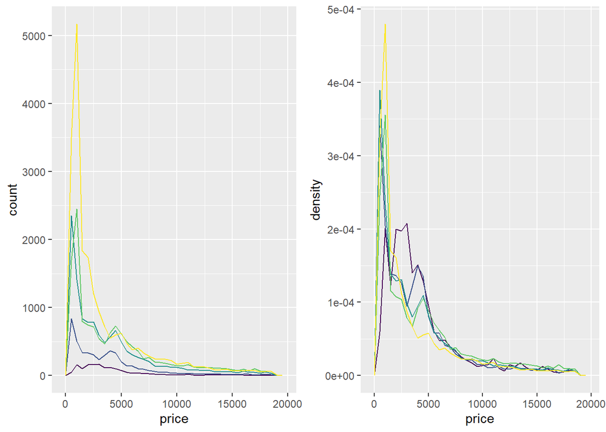

```r
library(ggplot2)
library(dplyr)
library(gridExtra)
library(mgcv)
library(MASS)
library(directlabels)

g1<-ggplot(diamonds, aes(price, colour = cut)) +
geom_freqpoly(binwidth = 500) +
theme(legend.position = "none")

g2<-ggplot(diamonds, aes(price, colour = cut)) +
geom_freqpoly(aes(y = ..density..), binwidth = 500) +
theme(legend.position = "none")

grid.arrange(g1,g2,ncol=2)
```

- The result of this plot is rather surprising: low quality diamonds seem to be more expensive on average. We’ll come back to this result in Sect. 11.2.

## Position Adjustments

- Position adjustments apply minor tweaks to the position of elements within a layer. Three adjustments apply primarily to bars:
1. position stack(): stack overlapping bars (or areas) on top of each other.
2. position fill(): stack overlapping bars, scaling so the top is always at 1.
3. position dodge(): place overlapping bars (or boxplots) side-by-side.

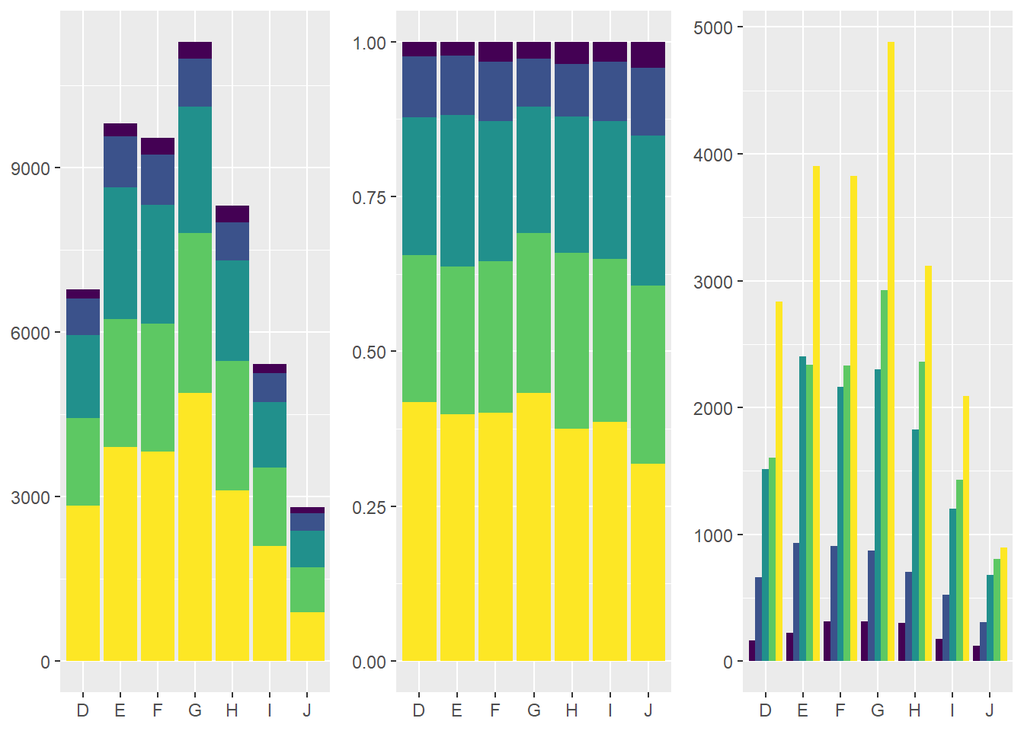

```r
library(ggplot2)
library(dplyr)
library(gridExtra)
library(mgcv)
library(MASS)
library(directlabels)

dplot <- ggplot(diamonds, aes(color, fill = cut)) +
xlab(NULL) + ylab(NULL) + theme(legend.position = "none")
# position stack is the default for bars, so geom_bar()
# is equivalent to geom_bar(position = "stack").
g1<-dplot + geom_bar()
g2<-dplot + geom_bar(position = "fill")
g3<-dplot + geom_bar(position = "dodge")

grid.arrange(g1,g2,g3,ncol=3)
```

- There’s also a position adjustment that does nothing: position identity(). The identity position adjustment isn’t useful for bars, because each bar obscures the bars behind, but there are many geoms that don’t need adjusting, like lines:

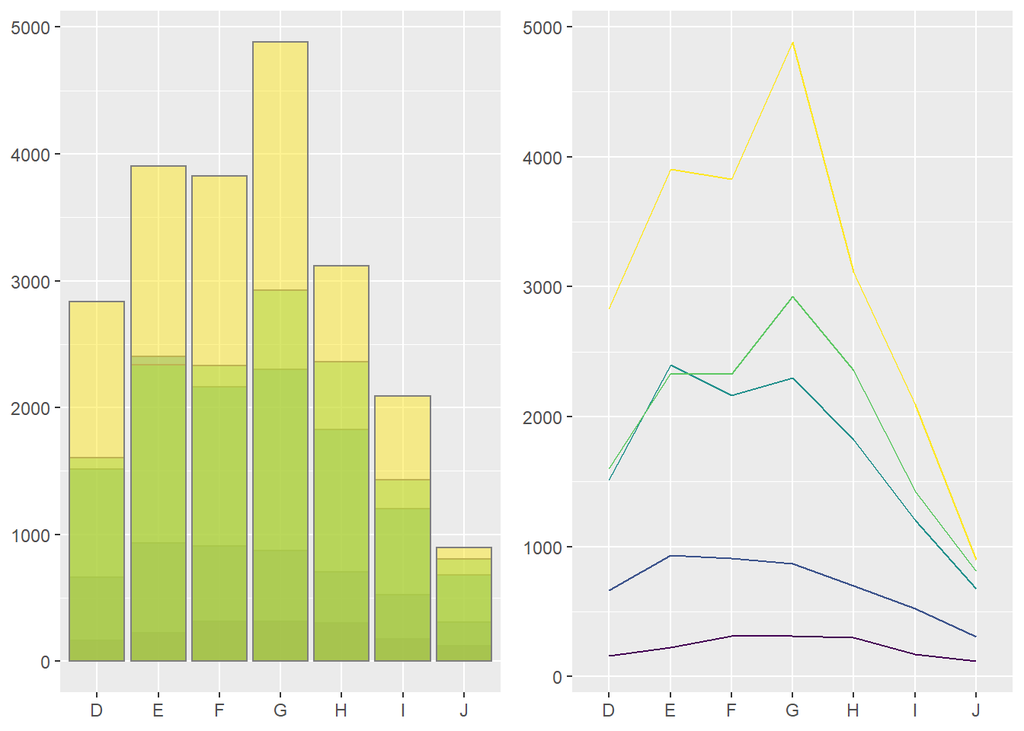

```r
library(ggplot2)
library(dplyr)
library(gridExtra)
library(mgcv)
library(MASS)
library(directlabels)

g1<-dplot + geom_bar(position = "identity", alpha = 1 / 2, colour = "grey50")

g2<-ggplot(diamonds, aes(color, colour = cut)) +
geom_line(aes(group = cut), stat = "count") +
xlab(NULL) + ylab(NULL) +
theme(legend.position = "none")

grid.arrange(g1,g2,ncol=2)
```

- There are three position adjustments that are primarily useful for points:
1. position nudge(): move points by a fixed offset.
2. position jitter(): add a little random noise to every position.
3. position jitterdodge(): dodge points within groups, then add a little random noise.
- Note that the way you pass parameters to position adjustments differs to stats and geoms. Instead of including additional arguments in …, you construct a position adjustment object, supplying additional arguments in the call:

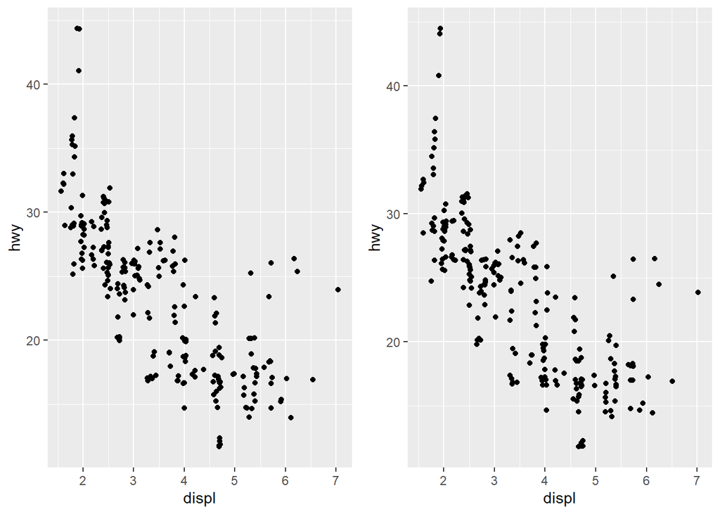

```r
library(ggplot2)
library(dplyr)
library(gridExtra)
library(mgcv)
library(MASS)
library(directlabels)

g1<-ggplot(mpg, aes(displ, hwy)) +
geom_point(position = "jitter")

g2<-ggplot(mpg, aes(displ, hwy)) +
geom_point(position = position_jitter(width = 0.05, height = 0.5))

grid.arrange(g1,g2,ncol=2)
```

- This is rather verbose, so geom jitter() provides a convenient shortcut:

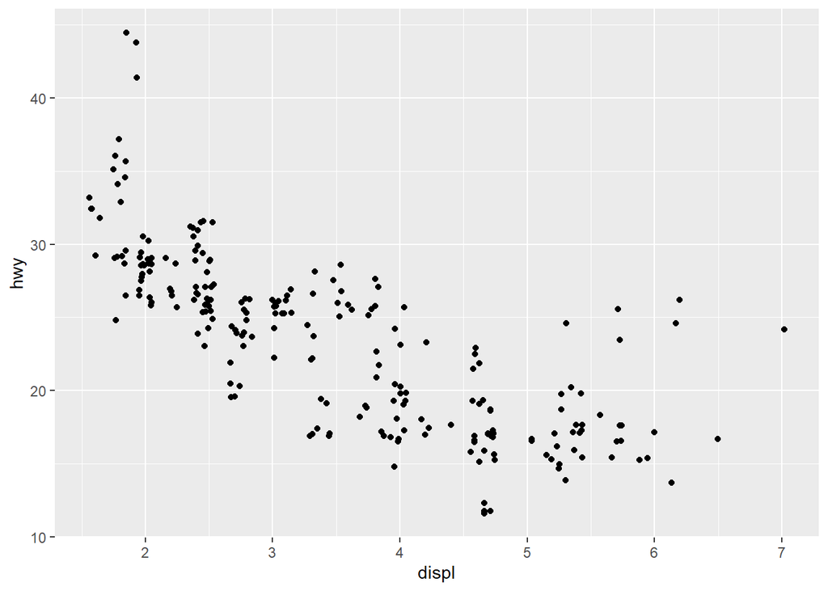

```r
library(ggplot2)
library(dplyr)
library(gridExtra)
library(mgcv)
library(MASS)
library(directlabels)

ggplot(mpg, aes(displ, hwy)) +
geom_jitter(width = 0.05, height = 0.5)
```

- Continuous data typically doesn’t overlap exactly, and when it does (because of high data density) minor adjustments, like jittering, are often insufficient to fix the problem. For this reason, position adjustments are generally most useful for discrete data.

## Scales, Axes and Legends

### Introduction

- Scales control the mapping from data to aesthetics. They take your data and turn it into something that you can see, like size, colour, position or shape. Scales also provide the tools that let you read the plot: the axes and legends. Formally, each scale is a function from a region in data space (the domain of the scale) to a region in aesthetic space (the range of the scale). The axis or legend is the inverse function: it allows you to convert visual properties back to data.

### Modifying Scales

- A scale is required for every aesthetic used on the plot. When you write:

```r
library(ggplot2)
library(dplyr)
library(gridExtra)
library(mgcv)
library(MASS)
library(directlabels)

ggplot(mpg, aes(displ, hwy)) +
geom_point(aes(colour = class))
```

- What actually happens is this:

```r
library(ggplot2)
library(dplyr)
library(gridExtra)
library(mgcv)
library(MASS)
library(directlabels)

ggplot(mpg, aes(displ, hwy)) +
geom_point(aes(colour = class)) +
scale_x_continuous() +
scale_y_continuous() +
scale_colour_discrete()
```

- Default scales are named according to the aesthetic and the variable type: scale y continuous(), scale colour discrete(), etc.
- It would be tedious to manually add a scale every time you used a new aesthetic, so ggplot2 does it for you. But if you want to override the defaults, you’ll need to add the scale yourself, like this:

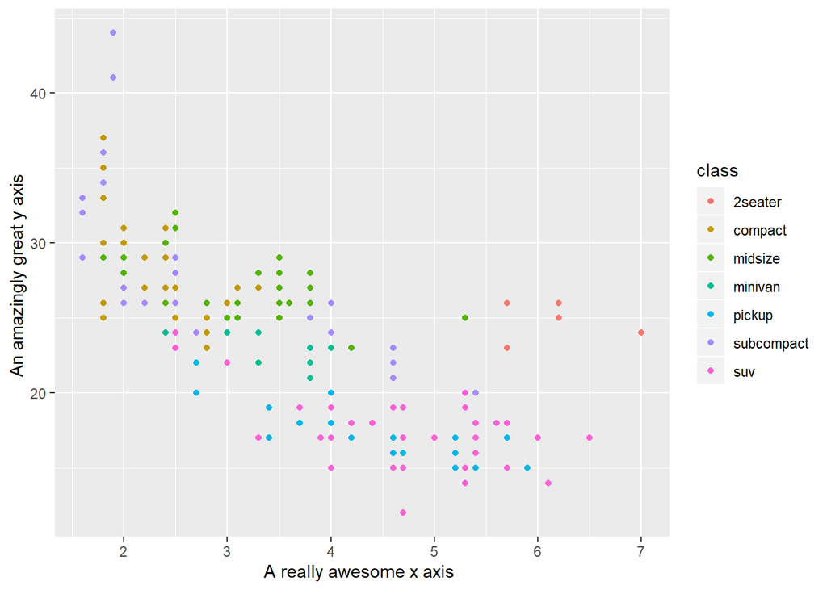

```r
library(ggplot2)
library(dplyr)
library(gridExtra)
library(mgcv)
library(MASS)
library(directlabels)

ggplot(mpg, aes(displ, hwy)) +
geom_point(aes(colour = class)) +
scale_x_continuous("A really awesome x axis ") +
scale_y_continuous("An amazingly great y axis ")
```

- The use of + to “add” scales to a plot is a little misleading. When you + a scale, you’re not actually adding it to the plot, but overriding the existing scale. This means that the following two specifications are equivalent:

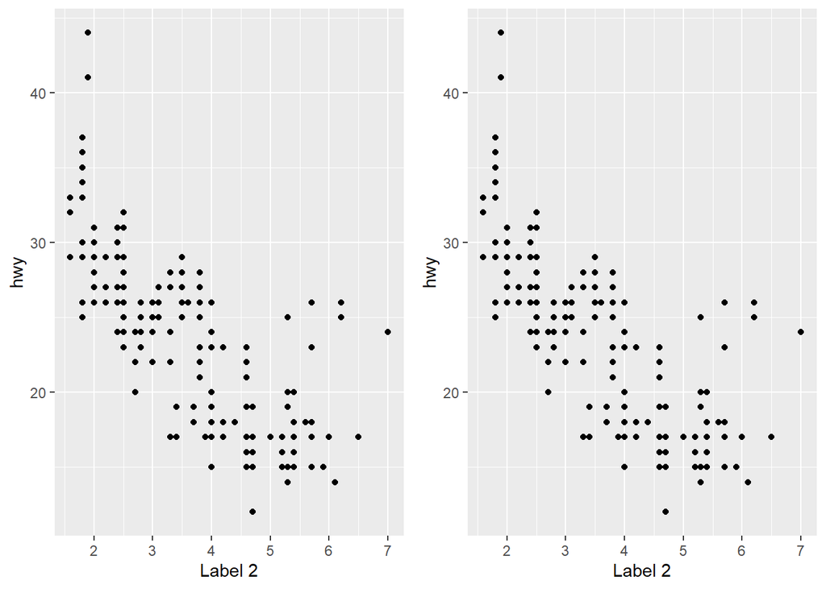

```r
library(ggplot2)
library(dplyr)
library(gridExtra)
library(mgcv)
library(MASS)
library(directlabels)

g1<-ggplot(mpg, aes(displ, hwy)) +
geom_point() +
scale_x_continuous("Label 1") +
scale_x_continuous("Label 2")

g2<-ggplot(mpg, aes(displ, hwy)) +
geom_point() +
scale_x_continuous("Label 2")

grid.arrange(g1,g2,ncol=2)
```

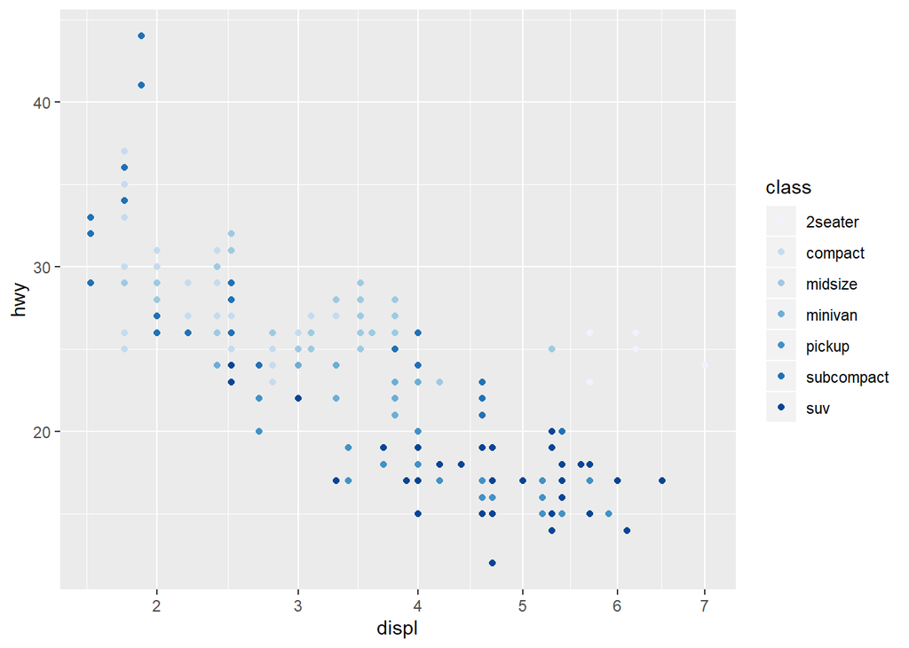

```r
library(ggplot2)
library(dplyr)
library(gridExtra)
library(mgcv)
library(MASS)
library(directlabels)

ggplot(mpg, aes(displ, hwy)) +
geom_point(aes(colour = class)) +
scale_x_sqrt() +
scale_colour_brewer()
```

- You’ve probably already figured out the naming scheme for scales, but to be concrete, it’s made up of three pieces separated by “ “:
1. scale.
2. The name of the aesthetic (e.g., colour, shape or x).
3. The name of the scale (e.g., continuous, discrete, brewer).

## Scale Title

- The first argument to the scale function, name, is the axes/legend title. You can supply text strings (using for line breaks) or mathematical expressions in quote() (as described in ?plotmath):

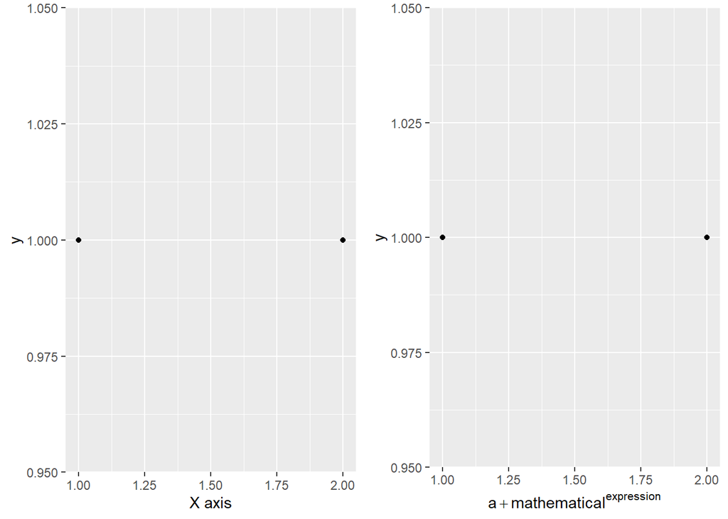

```r
library(ggplot2)
library(dplyr)
library(gridExtra)
library(mgcv)
library(MASS)
library(directlabels)

df <- data.frame(x = 1:2, y = 1, z = "a")
p <- ggplot(df, aes(x, y)) + geom_point()
g1<-p + scale_x_continuous("X axis")
g2<-p + scale_x_continuous(quote(a + mathematical ^ expression))

grid.arrange(g1,g2,ncol=2)
```

- Because tweaking these labels is such a common task, there are three helpers that save you some typing: xlab(), ylab() and labs():

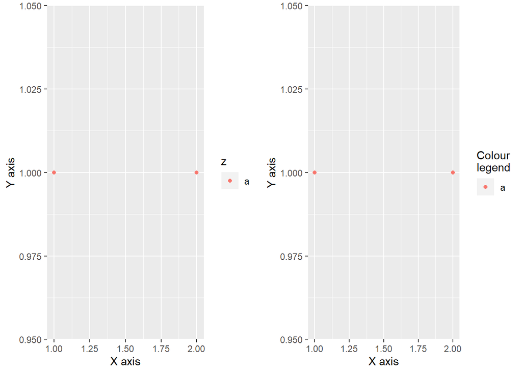

```r
library(ggplot2)
library(dplyr)
library(gridExtra)
library(mgcv)
library(MASS)
library(directlabels)

p <- ggplot(df, aes(x, y)) + geom_point(aes(colour = z))
g1<-p +
xlab("X axis") +
ylab("Y axis")
g2<-p + labs(x = "X axis", y = "Y axis", colour = "Colour\nlegend")

grid.arrange(g1,g2,ncol=2)
```

- There are two ways to remove the axis label. Setting it to "" omits the label, but still allocates space; NULL removes the label and its space. Look closely at the left and bottom borders of the following two plots. I’ve drawn a grey rectangle around the plot to make it easier to see the difference.

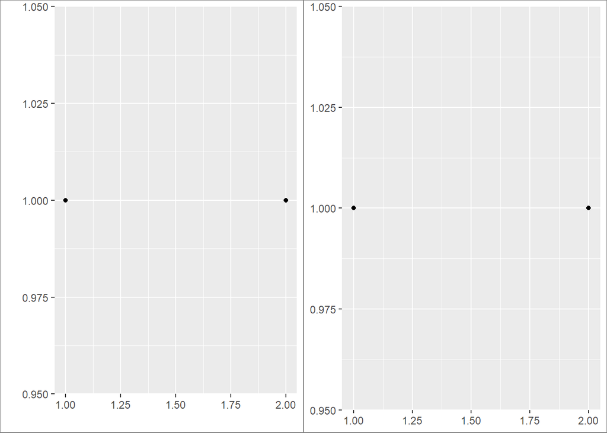

```r
library(ggplot2)
library(dplyr)
library(gridExtra)
library(mgcv)
library(MASS)
library(directlabels)

p <- ggplot(df, aes(x, y)) +
geom_point() +
theme(plot.background = element_rect(colour = "grey50"))
g1<-p + labs(x = "", y = "")

g2<-p + labs(x = NULL, y = NULL)

grid.arrange(g1,g2,ncol=2)
```

## Breaks and Labels

- The breaks argument controls which values appear as tick marks on axes and keys on legends. Each break has an associated label, controlled by the labels argument. If you set labels, you must also set breaks; otherwise, if data changes, the breaks will no longer align with the labels. The following code shows some basic examples for both axes and legends.

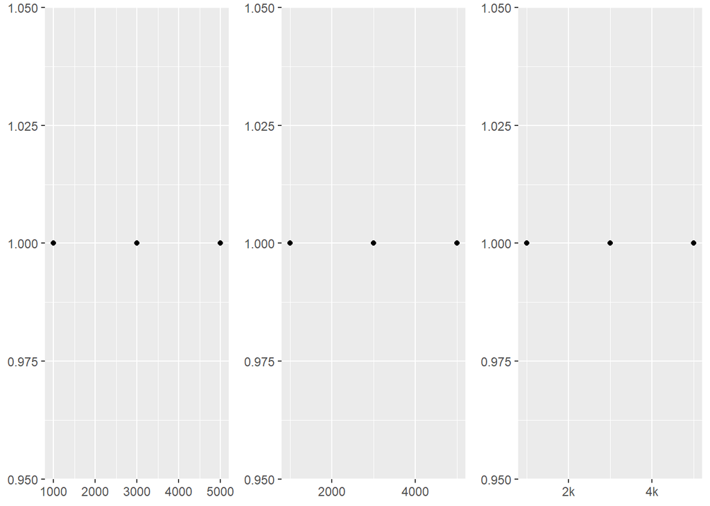

```r
library(ggplot2)
library(dplyr)
library(gridExtra)
library(mgcv)
library(MASS)
library(directlabels)

df <- data.frame(x = c(1, 3, 5) * 1000, y = 1)
axs <- ggplot(df, aes(x, y)) +
geom_point() +
labs(x = NULL, y = NULL)
g1<-axs
g2<-axs + scale_x_continuous(breaks = c(2000, 4000))
g3<-axs + scale_x_continuous(breaks = c(2000, 4000), labels = c("2k", "4k"))

grid.arrange(g1,g2,g3,ncol=3)
```

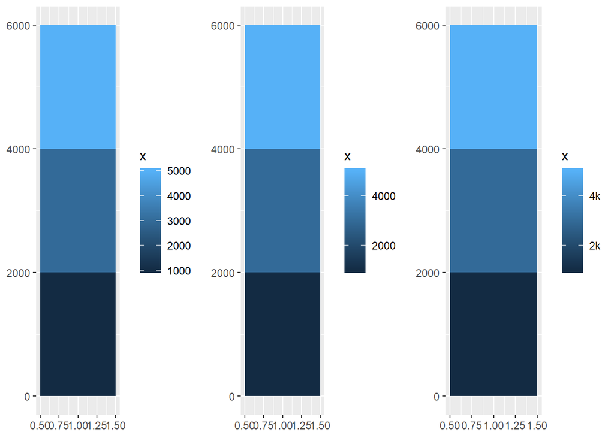

```r
leg <- ggplot(df, aes(y, x, fill = x)) +
geom_tile() +
labs(x = NULL, y = NULL)
g1<-leg
g2<-leg + scale_fill_continuous(breaks = c(2000, 4000))
g3<-leg + scale_fill_continuous(breaks = c(2000, 4000), labels = c("2k", "4k"))

grid.arrange(g1,g2,g3,ncol=3)
```

- If you want to relabel the breaks in a categorical scale, you can use a named labels vector:

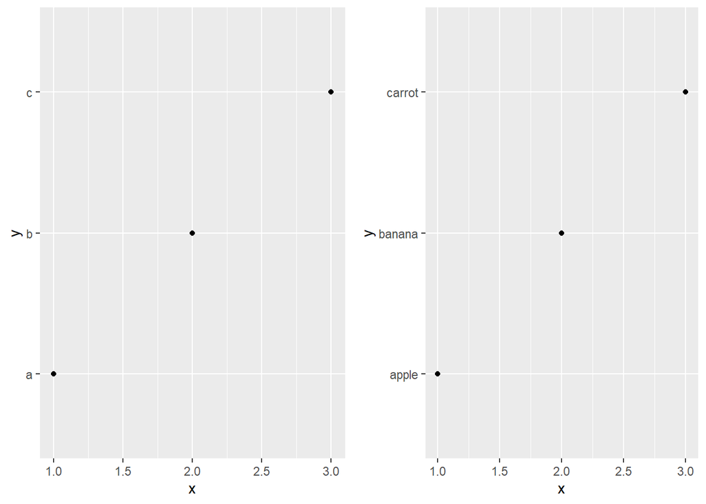

```r
library(ggplot2)
library(dplyr)
library(gridExtra)
library(mgcv)
library(MASS)
library(directlabels)

df2 <- data.frame(x = 1:3, y = c("a", "b", "c"))
g1<-ggplot(df2, aes(x, y)) +
geom_point()

g2<-ggplot(df2, aes(x, y)) +
geom_point() +
scale_y_discrete(labels = c(a = "apple", b = "banana", c = "carrot"))

grid.arrange(g1,g2,ncol=2)
```

- To suppress breaks (and for axes, grid lines) or labels, set them to NULL:

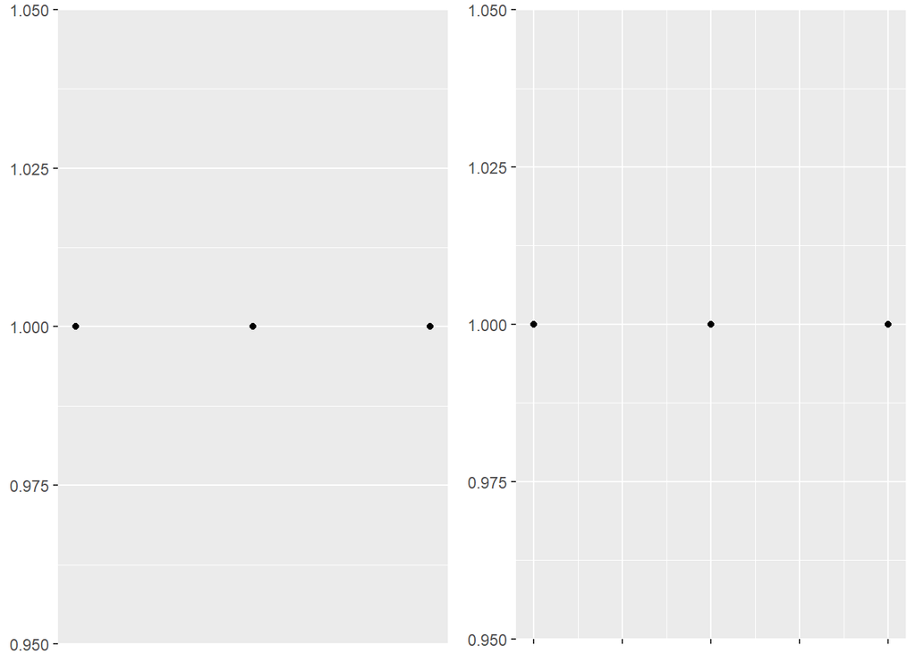

```r
library(ggplot2)
library(dplyr)
library(gridExtra)
library(mgcv)
library(MASS)
library(directlabels)

g1<-axs + scale_x_continuous(breaks = NULL)
g2<-axs + scale_x_continuous(labels = NULL)

grid.arrange(g1,g2,ncol=2)
```